# Inferencia de una variable discreta (conteo de andesitas): modelo de Poisson

Unidad 2 · Estadística inferencial · Geoquímica de rocas con datos de EarthChem PetDB

Cristoffer Rumiguano, Ana Gabriela Fernández, Evelyn Bustamante, Jessica Haro, Jhonattan Ligña

Noviembre de 2026

> Proyecto estrictamente académico (Estadística y Probabilidades, FIGEMPA – UCE). Datos: EarthChem PetDB (CC BY 4.0), descargados el 13/10/2026. Web del proyecto: https://crisrumiguano-art.github.io/geoquimica-earthchem-ml/

## 1. Carga de datos

La inferencia se hace con la **muestra aleatoria simple** de la Lección 3: 1 061 porciones de roca sorteadas de las 159 760 de la base (semilla 2026). Con la base entera, el test de chi-cuadrado rechaza cualquier modelo por diferencias mínimas; con una muestra aleatoria mide lo que importa.

**Población, marco muestral y muestra.** La población (U) son todas las porciones de roca de la corteza y del manto superior de la Tierra: es infinita y nunca se conoce. El **marco muestral** es la base EarthChem PetDB (159 760 porciones de roca registradas): la lista de la que se sorteó la muestra. Por eso, en rigor, la inferencia vale para la población que representa la base, con su sesgo hacia las rocas oceánicas (Lección 3). Al final, la base completa sirve para **validar el método**: si el intervalo calculado con la muestra contiene el valor del marco, el procedimiento funcionó.

```r
knitr::opts_chunk$set(echo = TRUE, message = FALSE, warning = FALSE, fig.align = "center")
library(MASS)          # fitdistr(): estima los parámetros del modelo (viene con R)
dir.create("data/muestras", recursive = TRUE, showWarnings = FALSE)
if (!file.exists("data/muestras/muestra_aleatoria.csv")) {
  download.file("https://github.com/crisrumiguano-art/geoquimica-earthchem-ml/raw/main/data/muestras/muestra_aleatoria.csv", "data/muestras/muestra_aleatoria.csv", mode = "wb")
}
muestra <- read.csv("data/muestras/muestra_aleatoria.csv", check.names = FALSE)
dim(muestra)           # filas y columnas
```

```
## [1] 1061   76
```

## 2. Tabla de distribución de cantidad

Variable **discreta**: el número de rocas volcánicas intermedias (andesitas) en un lote de 30 porciones de roca. Es un conteo de un evento poco frecuente (cerca del 6 % de las rocas). Antes se probó con N Analytes (número de analitos) y **no sirvió**: su varianza (122) es once veces su media (10,8) y el modelo de Poisson exige que sean iguales; el chi-cuadrado salió miles de veces mayor que el umbral.

```r
x <- as.character(muestra[["Sample Type"]])
x <- x[!is.na(x) & x != ""]                            # quita vacíos (en el orden del sorteo)
exito <- x == "igneous:volcanic:intermediate"                            # TRUE = rocas volcánicas intermedias
c(casos = length(x), exitos = sum(exito), proporcion = mean(exito))
```

```
##        casos       exitos   proporcion
## 1.061000e+03 6.000000e+01 5.655042e-02
```

```r
lote <- 30
B <- floor(length(exito) / lote)
grupo <- rep(1:B, each = lote)
y <- as.vector(tapply(exito[1:(B * lote)], grupo, sum))  # andesitas en cada lote de 30
c(media = mean(y), varianza = var(y))                  # en Poisson deben ser parecidas
```

```
##    media varianza
## 1.714286 1.680672
```

```r
Fo <- as.vector(table(factor(y, levels = 0:max(y))))   # cuántas veces salió 0, 1, 2, ...
hi <- round(Fo / sum(Fo) * 100, 2)
TDF <- data.frame(valor = 0:max(y), ni = Fo, hi)
knitr::kable(TDF, caption = "Tabla N° 1: distribución de X = rocas intermedias en un lote de 30")
```

Tabla N° 1: distribución de X = rocas intermedias en un lote de 30

| valor | ni | hi |
| --- | --- | --- |
| 0 | 5 | 14.29 |
| 1 | 13 | 37.14 |
| 2 | 9 | 25.71 |
| 3 | 5 | 14.29 |
| 4 | 1 | 2.86 |
| 5 | 2 | 5.71 |

## 3. Gráfica de distribución de cantidad

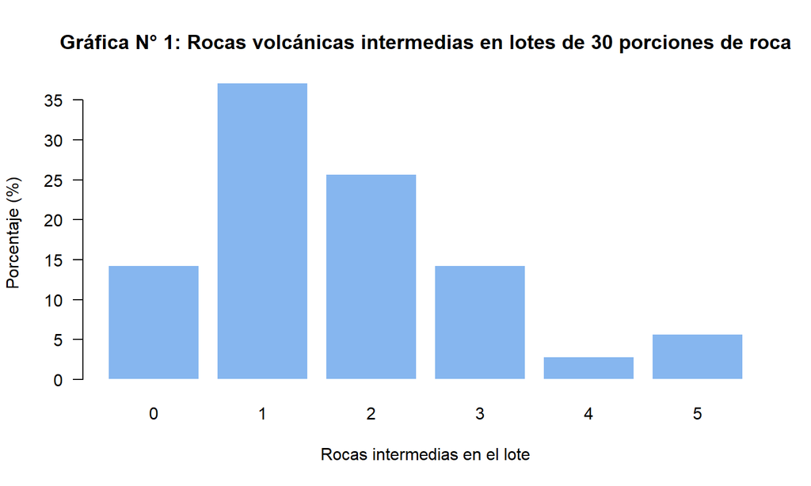

```r
barplot(hi, names.arg = 0:max(y), col = "#86b6ef", border = "white", las = 1,
        main = "Gráfica N° 1: Rocas volcánicas intermedias en lotes de 30 porciones de roca", xlab = "Rocas intermedias en el lote", ylab = "Porcentaje (%)")
```

## 4. Conjetura del modelo

X cuenta un evento raro en un lote grande y su media y varianza son parecidas: es el **modelo de Poisson**. λ se estima con la media.

```r
lambda <- mean(y)                                     # promedio de andesitas por lote
lambda
```

```
## [1] 1.714286
```

```r
valores <- 0:max(y)
P <- dpois(valores, lambda)                                        # probabilidad de cada valor según el modelo
P[length(P)] <- 1 - ppois(max(y) - 1, lambda)                                # el último valor acumula la cola ("o más")
Fe <- P * length(y)                                    # frecuencia esperada
# Para el chi-cuadrado cada clase debe esperar al menos 5 casos: los valores altos se juntan en una clase "o más"
corte <- max(which(Fe >= 5))
Fo2 <- c(Fo[1:(corte - 1)], sum(Fo[corte:length(Fo)]))
Fe2 <- c(Fe[1:(corte - 1)], sum(Fe[corte:length(Fe)]))
clase <- c(0:(corte - 2), paste0(corte - 1, " o más"))
knitr::kable(data.frame(clase, Fo = Fo2, Fe = round(Fe2, 2)), caption = "Tabla N° 2: frecuencias observadas y esperadas")
```

Tabla N° 2: frecuencias observadas y esperadas

| clase | Fo | Fe |
| --- | --- | --- |
| 0 | 5 | 6.30 |
| 1 | 13 | 10.81 |
| 2 | 9 | 9.26 |
| 3 o más | 8 | 8.63 |

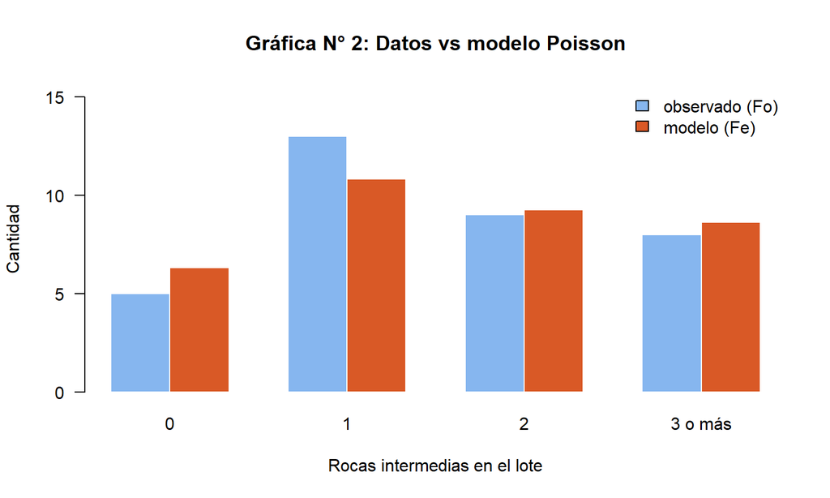

```r
barplot(rbind(Fo2, Fe2), beside = TRUE, names.arg = clase, col = c("#86b6ef", "#d95926"), border = "white", las = 1,
        ylim = c(0, max(Fo2, Fe2) * 1.2),
        main = "Gráfica N° 2: Datos vs modelo Poisson", xlab = "Rocas intermedias en el lote", ylab = "Cantidad")
legend("topright", c("observado (Fo)", "modelo (Fe)"), fill = c("#86b6ef", "#d95926"), bty = "n")
```

## 5. Test de aprobación

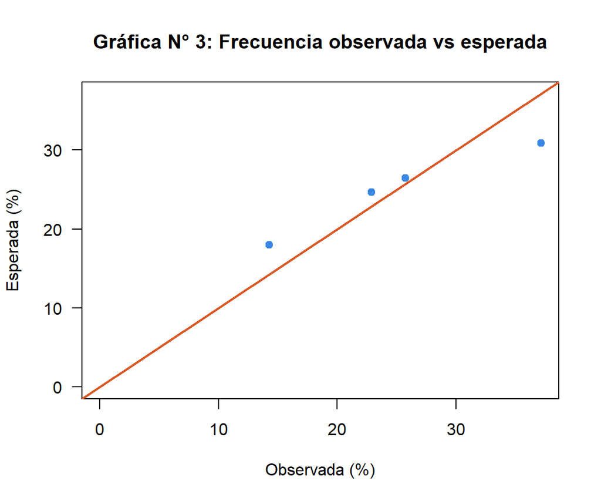

```r
lim <- range(0, Fo2 / sum(Fo2) * 100, Fe2 / sum(Fo2) * 100)   # mismos ejes en x e y
plot(Fo2 / sum(Fo2) * 100, Fe2 / sum(Fo2) * 100, pch = 19, col = "#3987e5", las = 1, xlim = lim, ylim = lim,
     main = "Gráfica N° 3: Frecuencia observada vs esperada", xlab = "Observada (%)", ylab = "Esperada (%)")
abline(a = 0, b = 1, col = "#d95926", lwd = 2)
```

```r
pearson <- cor(Fo2, Fe2) * 100
gl <- length(Fo2) - 1
x2 <- sum((Fo2 - Fe2)^2 / Fe2)
umbral <- qchisq(0.95, gl)
resultado <- ifelse(x2 < umbral, "se acepta el modelo", "se rechaza el modelo")
knitr::kable(data.frame(Variable = "X = rocas intermedias en un lote de 30", Pearson = round(pearson, 2), Chi_cuadrado = round(x2, 2),
                        Umbral = round(umbral, 2), Resultado = resultado),
             caption = "Tabla N° 3: pruebas de bondad de ajuste")
```

Tabla N° 3: pruebas de bondad de ajuste

| Variable | Pearson | Chi_cuadrado | Umbral | Resultado |
| --- | --- | --- | --- | --- |
| X = rocas intermedias en un lote de 30 | 97.82 | 0.77 | 7.81 | se acepta el modelo |

El chi-cuadrado (0.77) es menor que el umbral (7.81): se acepta el modelo. La correlación entre lo observado y lo esperado es de 97.8 %.

## 6. Estimación de probabilidades

**En un lote de 30 porciones de roca, ¿cuál es la probabilidad de que no haya ninguna roca intermedia?**

```r
p1 <- dpois(0, lambda)
p1 * 100
```

```
## [1] 18.00923
```

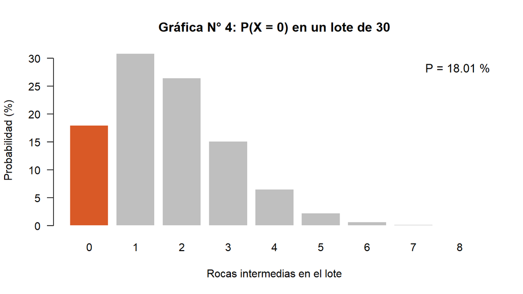

```r
vp <- 0:8                                       # valores posibles que se dibujan
Pp <- dpois(vp, lambda)
barplot(Pp * 100, names.arg = vp, las = 1, border = "white", col = ifelse(vp == 0, "#d95926", "gray75"),
        main = "Gráfica N° 4: P(X = 0) en un lote de 30", xlab = "Rocas intermedias en el lote", ylab = "Probabilidad (%)")
legend("topright", paste0("P = ", round(p1 * 100, 2), " %"), bty = "n", cex = 1.1)
```

**En 50 lotes de 30 porciones de roca, ¿en cuántos habría 3 o más rocas intermedias?**

```r
p3 <- 1 - ppois(2, lambda)
c(probabilidad = p3 * 100, lotes_esperados_de_50 = p3 * 50)
```

```
##          probabilidad lotes_esperados_de_50
##              24.65526              12.32763
```

## 7. Intervalos de confianza

Intervalo de confianza del 95 % para la **proporción poblacional** de rocas intermedias (λ / 30), con la aproximación normal.

```r
p_m <- mean(exito)                                     # proporción en la muestra
z <- qnorm(0.975)
E <- z * sqrt(p_m * (1 - p_m) / length(exito))         # error máximo de estimación
IC <- c(inferior = p_m - E, proporcion = p_m, superior = p_m + E)
round(IC * 100, 2)                                     # en %
```

```
##   inferior proporcion   superior
##       4.27       5.66       7.04
```

**Validación con el marco muestral.** La proporción en toda la base (el marco del que se sorteó la muestra) sí se puede calcular: ¿el intervalo de la muestra la contiene? Es una prueba del método, no la proporción de la población.

```r
if (!file.exists("data/earthchem_limpio.csv.gz")) {
  download.file("https://github.com/crisrumiguano-art/geoquimica-earthchem-ml/raw/main/data/earthchem_limpio.csv.gz", "data/earthchem_limpio.csv.gz", mode = "wb")
}
base <- read.csv(gzfile("data/earthchem_limpio.csv.gz", encoding = "UTF-8"), check.names = FALSE)
todos <- as.character(base[["Sample Type"]])
todos <- todos[!is.na(todos) & todos != ""]
p_marco <- mean(todos == "igneous:volcanic:intermediate")
c(proporcion_marco = p_marco, dentro_del_intervalo = p_marco >= IC[["inferior"]] & p_marco <= IC[["superior"]])
```

```
##     proporcion_marco dentro_del_intervalo
##           0.05831643           1.00000000
```

## 8. Conclusión

El número de rocas volcánicas intermedias en un lote de 30 porciones de roca sigue un **modelo de Poisson** con λ = 1.71. El modelo pasa el test (chi-cuadrado 0.77 < umbral 7.81; Pearson 97.8 %). Con el 95 % de confianza, la proporción poblacional de rocas volcánicas intermedias está entre 4.27 % y 7.04 %, y la proporción del marco muestral (5.83 %, toda la base) cae dentro del intervalo.